# Analysis of crime in NYC

Importing the tools and libraries required

```python
import pandas as pd
import numpy as np
import folium as fl
import matplotlib.pyplot as plt
import seaborn as sns
from folium.plugins import HeatMap, MarkerCluster
```

```python
df = pd.read_csv('NYPD_Complaint_Data_Historic.csv')
demograpics_borough = pd.read_csv('NYPD_Complaint_Data_Historic.csv')
```

```python
print("Number of data points: ",len(df))
```

```
Number of data points:  7825499
```

```python
print("Our initial columns: ", list(df.columns))
```

[output not shown]

```python
df.head()
```

|  | CMPLNT_NUM | CMPLNT_FR_DT | CMPLNT_FR_TM | CMPLNT_TO_DT | CMPLNT_TO_TM | ADDR_PCT_CD | RPT_DT | KY_CD | OFNS_DESC | PD_CD | ... | SUSP_SEX | TRANSIT_DISTRICT | Latitude | Longitude | Lat_Lon | PATROL_BORO | STATION_NAME | VIC_AGE_GROUP | VIC_RACE | VIC_SEX |
| --- | --- | --- | --- | --- | --- | --- | --- | --- | --- | --- | --- | --- | --- | --- | --- | --- | --- | --- | --- | --- | --- |
| 0 | 506547392 | 03/29/2018 | 20:30:00 | NaN | NaN | 32.0 | 03/30/2018 | 351 | CRIMINAL MISCHIEF & RELATED OF | 254.0 | ... | NaN | NaN | 40.810877 | -73.941064 | (40.810877241, -73.941064151) | PATROL BORO MAN NORTH | NaN | 25-44 | WHITE | F |
| 1 | 629632833 | 02/06/2018 | 23:15:00 | NaN | NaN | 52.0 | 02/07/2018 | 341 | PETIT LARCENY | 333.0 | ... | F | NaN | 40.873671 | -73.908014 | (40.873671035, -73.908013649) | PATROL BORO BRONX | NaN | UNKNOWN | UNKNOWN | D |
| 2 | 787203902 | 11/21/2018 | 00:15:00 | 11/21/2018 | 00:20:00 | 75.0 | 11/21/2018 | 341 | PETIT LARCENY | 321.0 | ... | F | NaN | 40.651782 | -73.885457 | (40.651782232, -73.885456761) | PATROL BORO BKLYN NORTH | NaN | UNKNOWN | UNKNOWN | D |
| 3 | 280364018 | 06/09/2018 | 21:42:00 | 06/09/2018 | 21:43:00 | 10.0 | 06/10/2018 | 361 | OFF. AGNST PUB ORD SENSBLTY & | 639.0 | ... | M | NaN | 40.759310 | -73.994706 | (40.759310399, -73.994706072) | PATROL BORO MAN SOUTH | NaN | 18-24 | WHITE HISPANIC | F |
| 4 | 985800320 | 11/10/2018 | 19:40:00 | 11/10/2018 | 19:45:00 | 19.0 | 11/10/2018 | 341 | PETIT LARCENY | 333.0 | ... | F | NaN | 40.764536 | -73.970728 | (40.764535539, -73.970728388) | PATROL BORO MAN NORTH | NaN | UNKNOWN | UNKNOWN | D |

5 rows × 35 columns

In this data set, there are two times listed, when the case was opened and when it was close. For the sake of simplicity, we will only be concerning ourselves when the crime was first reported, because we want to be as close to the time where the crime actually occured We should also go ahead and remove any 'codes' as they won't be super useful when we conduct any analysis

```python
df = df.drop(columns=['CMPLNT_TO_DT', 'CMPLNT_TO_TM','RPT_DT','ADDR_PCT_CD',
                      'KY_CD','PD_CD','JURISDICTION_CODE','PARKS_NM','HOUSING_PSA',
                      'X_COORD_CD', 'Y_COORD_CD'])
df.head()
```

|  | CMPLNT_NUM | CMPLNT_FR_DT | CMPLNT_FR_TM | OFNS_DESC | PD_DESC | CRM_ATPT_CPTD_CD | LAW_CAT_CD | BORO_NM | LOC_OF_OCCUR_DESC | PREM_TYP_DESC | ... | SUSP_SEX | TRANSIT_DISTRICT | Latitude | Longitude | Lat_Lon | PATROL_BORO | STATION_NAME | VIC_AGE_GROUP | VIC_RACE | VIC_SEX |
| --- | --- | --- | --- | --- | --- | --- | --- | --- | --- | --- | --- | --- | --- | --- | --- | --- | --- | --- | --- | --- | --- |
| 0 | 506547392 | 03/29/2018 | 20:30:00 | CRIMINAL MISCHIEF & RELATED OF | MISCHIEF, CRIMINAL 4, OF MOTOR | COMPLETED | MISDEMEANOR | MANHATTAN | FRONT OF | PARKING LOT/GARAGE (PUBLIC) | ... | NaN | NaN | 40.810877 | -73.941064 | (40.810877241, -73.941064151) | PATROL BORO MAN NORTH | NaN | 25-44 | WHITE | F |
| 1 | 629632833 | 02/06/2018 | 23:15:00 | PETIT LARCENY | LARCENY,PETIT FROM STORE-SHOPL | COMPLETED | MISDEMEANOR | BRONX | INSIDE | DEPARTMENT STORE | ... | F | NaN | 40.873671 | -73.908014 | (40.873671035, -73.908013649) | PATROL BORO BRONX | NaN | UNKNOWN | UNKNOWN | D |
| 2 | 787203902 | 11/21/2018 | 00:15:00 | PETIT LARCENY | LARCENY,PETIT FROM AUTO | COMPLETED | MISDEMEANOR | BROOKLYN | FRONT OF | STREET | ... | F | NaN | 40.651782 | -73.885457 | (40.651782232, -73.885456761) | PATROL BORO BKLYN NORTH | NaN | UNKNOWN | UNKNOWN | D |
| 3 | 280364018 | 06/09/2018 | 21:42:00 | OFF. AGNST PUB ORD SENSBLTY & | AGGRAVATED HARASSMENT 2 | COMPLETED | MISDEMEANOR | MANHATTAN | INSIDE | RESIDENCE - APT. HOUSE | ... | M | NaN | 40.759310 | -73.994706 | (40.759310399, -73.994706072) | PATROL BORO MAN SOUTH | NaN | 18-24 | WHITE HISPANIC | F |
| 4 | 985800320 | 11/10/2018 | 19:40:00 | PETIT LARCENY | LARCENY,PETIT FROM STORE-SHOPL | COMPLETED | MISDEMEANOR | MANHATTAN | INSIDE | CHAIN STORE | ... | F | NaN | 40.764536 | -73.970728 | (40.764535539, -73.970728388) | PATROL BORO MAN NORTH | NaN | UNKNOWN | UNKNOWN | D |

5 rows × 24 columns

We should also rename the columns, as their current state is not super descriptive

```python
d = {'CMPLNT_FR_DT':'Date','CMPLNT_FR_TM':'Time','OFNS_DESC':'Offense Description','CMPLNT_NUM':'ID',
     'LOC_OF_OCCUR_DESC':'Location Description','PD_DESC':'Granular Offense Description',
    'BORO_NM':'Borough','CRM_ATPT_CPTD_CD':'Crime Attempted','SUSP_SEX':'Suspect Sex',
    'PREM_TYP_DESC':'Premise Description','STATION_NAME':'Station Name','PATROL_BORO':'Patrol Borough',
    'VIC_AGE_GROUP':'Victim Age Group','VIC_RACE':'Victim Race','VIC_SEX':'Victim Sex',
    'TRANSIT_DISTRICT':'Transit District','JURIS_DESC':'Jurisdiction description','LAW_CAT_CD':'Level of Offense',
    'HADEVELOPT':'Housing Development','SUSP_AGE_GROUP':'Suspect Age Group', 'SUSP_RACE':'Suspect Race'}
df = df.rename(columns=d)
df.head()
```

|  | ID | Date | Time | Offense Description | Granular Offense Description | Crime Attempted | Level of Offense | Borough | Location Description | Premise Description | ... | Suspect Sex | Transit District | Latitude | Longitude | Lat_Lon | Patrol Borough | Station Name | Victim Age Group | Victim Race | Victim Sex |
| --- | --- | --- | --- | --- | --- | --- | --- | --- | --- | --- | --- | --- | --- | --- | --- | --- | --- | --- | --- | --- | --- |
| 0 | 506547392 | 03/29/2018 | 20:30:00 | CRIMINAL MISCHIEF & RELATED OF | MISCHIEF, CRIMINAL 4, OF MOTOR | COMPLETED | MISDEMEANOR | MANHATTAN | FRONT OF | PARKING LOT/GARAGE (PUBLIC) | ... | NaN | NaN | 40.810877 | -73.941064 | (40.810877241, -73.941064151) | PATROL BORO MAN NORTH | NaN | 25-44 | WHITE | F |
| 1 | 629632833 | 02/06/2018 | 23:15:00 | PETIT LARCENY | LARCENY,PETIT FROM STORE-SHOPL | COMPLETED | MISDEMEANOR | BRONX | INSIDE | DEPARTMENT STORE | ... | F | NaN | 40.873671 | -73.908014 | (40.873671035, -73.908013649) | PATROL BORO BRONX | NaN | UNKNOWN | UNKNOWN | D |
| 2 | 787203902 | 11/21/2018 | 00:15:00 | PETIT LARCENY | LARCENY,PETIT FROM AUTO | COMPLETED | MISDEMEANOR | BROOKLYN | FRONT OF | STREET | ... | F | NaN | 40.651782 | -73.885457 | (40.651782232, -73.885456761) | PATROL BORO BKLYN NORTH | NaN | UNKNOWN | UNKNOWN | D |
| 3 | 280364018 | 06/09/2018 | 21:42:00 | OFF. AGNST PUB ORD SENSBLTY & | AGGRAVATED HARASSMENT 2 | COMPLETED | MISDEMEANOR | MANHATTAN | INSIDE | RESIDENCE - APT. HOUSE | ... | M | NaN | 40.759310 | -73.994706 | (40.759310399, -73.994706072) | PATROL BORO MAN SOUTH | NaN | 18-24 | WHITE HISPANIC | F |
| 4 | 985800320 | 11/10/2018 | 19:40:00 | PETIT LARCENY | LARCENY,PETIT FROM STORE-SHOPL | COMPLETED | MISDEMEANOR | MANHATTAN | INSIDE | CHAIN STORE | ... | F | NaN | 40.764536 | -73.970728 | (40.764535539, -73.970728388) | PATROL BORO MAN NORTH | NaN | UNKNOWN | UNKNOWN | D |

5 rows × 24 columns

In order to make use of the date and time column, we must also cast to python datetime object, so we join the Date and Time columns, and format to daetime

```python
df['Date'] = df['Date'] + ' ' + df['Time']
df = df.drop(columns = 'Time')
df['Date'] = pd.to_datetime(df['Date'], format = "%m/%d/%Y %H:%M:%S", errors='coerce')
df = df.sort_values(by='Date', ascending=False).reset_index(drop=True)
df = df[df['Date'].isna() == False]
df = df[df['Date'] > pd.to_datetime("1/1/2006")]
df.head()
```

|  | ID | Date | Offense Description | Granular Offense Description | Crime Attempted | Level of Offense | Borough | Location Description | Premise Description | Jurisdiction description | ... | Suspect Sex | Transit District | Latitude | Longitude | Lat_Lon | Patrol Borough | Station Name | Victim Age Group | Victim Race | Victim Sex |
| --- | --- | --- | --- | --- | --- | --- | --- | --- | --- | --- | --- | --- | --- | --- | --- | --- | --- | --- | --- | --- | --- |
| 0 | 497679206 | 2021-12-31 23:50:00 | GRAND LARCENY | LARCENY,GRAND FROM PERSON,PICK | COMPLETED | FELONY | MANHATTAN | NaN | STREET | N.Y. POLICE DEPT | ... | U | NaN | 40.754849 | -73.984120 | (40.754849215000036, -73.98411999099994) | PATROL BORO MAN SOUTH | NaN | 25-44 | ASIAN / PACIFIC ISLANDER | M |
| 1 | 538683331 | 2021-12-31 23:48:00 | FELONY ASSAULT | ASSAULT 2,1,UNCLASSIFIED | COMPLETED | FELONY | BROOKLYN | NaN | STREET | N.Y. POLICE DEPT | ... | U | NaN | 40.629443 | -73.967077 | (40.62944258800008, -73.96707691399996) | PATROL BORO BKLYN SOUTH | NaN | 45-64 | ASIAN / PACIFIC ISLANDER | M |
| 2 | 991986193 | 2021-12-31 23:40:00 | GRAND LARCENY | LARCENY,GRAND FROM PERSON,PICK | COMPLETED | FELONY | MANHATTAN | NaN | STREET | N.Y. POLICE DEPT | ... | U | NaN | 40.754849 | -73.984120 | (40.754849215000036, -73.98411999099994) | PATROL BORO MAN SOUTH | NaN | 25-44 | WHITE HISPANIC | M |
| 3 | 740369134 | 2021-12-31 23:35:00 | DANGEROUS WEAPONS | WEAPONS POSSESSION 1 & 2 | COMPLETED | FELONY | BRONX | FRONT OF | STREET | N.Y. POLICE DEPT | ... | NaN | NaN | 40.853323 | -73.902891 | (40.853323123000045, -73.90289074399993) | PATROL BORO BRONX | NaN | UNKNOWN | UNKNOWN | E |
| 4 | 533919417 | 2021-12-31 23:30:00 | ASSAULT 3 & RELATED OFFENSES | ASSAULT 3 | COMPLETED | MISDEMEANOR | BRONX | INSIDE | GROCERY/BODEGA | N.Y. POLICE DEPT | ... | F | NaN | 40.832893 | -73.875410 | (40.832892539000056, -73.87540977699997) | PATROL BORO BRONX | NaN | <18 | WHITE HISPANIC | M |

5 rows × 23 columns

I also noticed that some of the offense descriptions were somewhat specific, so I added a more general offense column

```python
df['Offense'] = 'Other'

def f(x):
    if x in ['RAPE','LOITERING/DEVIATE SEX','SEX CRIMES','FELONY SEX CRIMES']:
        return 'Sexual Assault and Rape'
    elif x in ['ASSAULT 3 & RELATED OFFENSES','FELONY ASSAULT']:
        return 'Assault'
    elif x in ['KIDNAPPING','KIDNAPPING & RELATED OFFENSES','KIDNAPPING AND RELATED OFFENSES']:
        return 'Kidnapping'
    elif x in ['MURDER & NON-NEGL. MANSLAUGHTER','HOMICIDE-NEGLIGENT,UNCLASSIFIE']:
        return 'Homicide'
    elif x in ['INTOXICATED & IMPAIRED DRIVING','INTOXICATED/IMPAIRED DRIVING','HOMICIDE-NEGLIGENT-VEHICLE']:
        return 'Impaired Driving'
    elif x in ['ROBBERY',"BURGLAR'S TOOLS",'BURGLARY','PETIT LARCENY','PETIT LARCENY OF MOTOR VEHICLE',
               'POSSESSION OF STOLEN PROPERTY','THEFT OF SERVICES','THEFT-FRAUD']:
        return "Robbery and Theft"
    elif x is 'ARSON':
        return 'Arson'
    else:
        return 'Other'


df['Offense'] = df['Offense Description'].apply(f)

df.head()
```

[output not shown]

5 rows × 24 columns

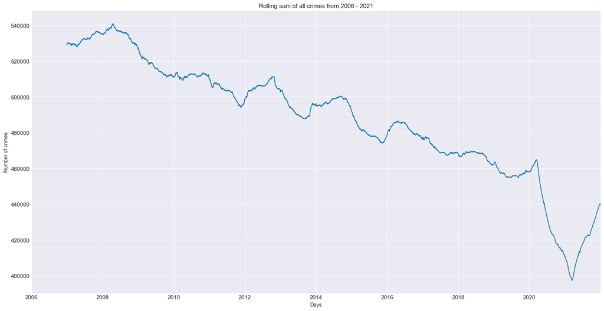

```python
plt.figure(figsize=(20,10))
df.index = df['Date']
df.resample('D').size().rolling(365).sum().plot()
plt.title(f"Rolling sum of all crimes from {df.iloc[-1]['Date'].year} - {df.iloc[0]['Date'].year}")
plt.ylabel('Number of crimes')
plt.xlabel('Days')
plt.show()
```

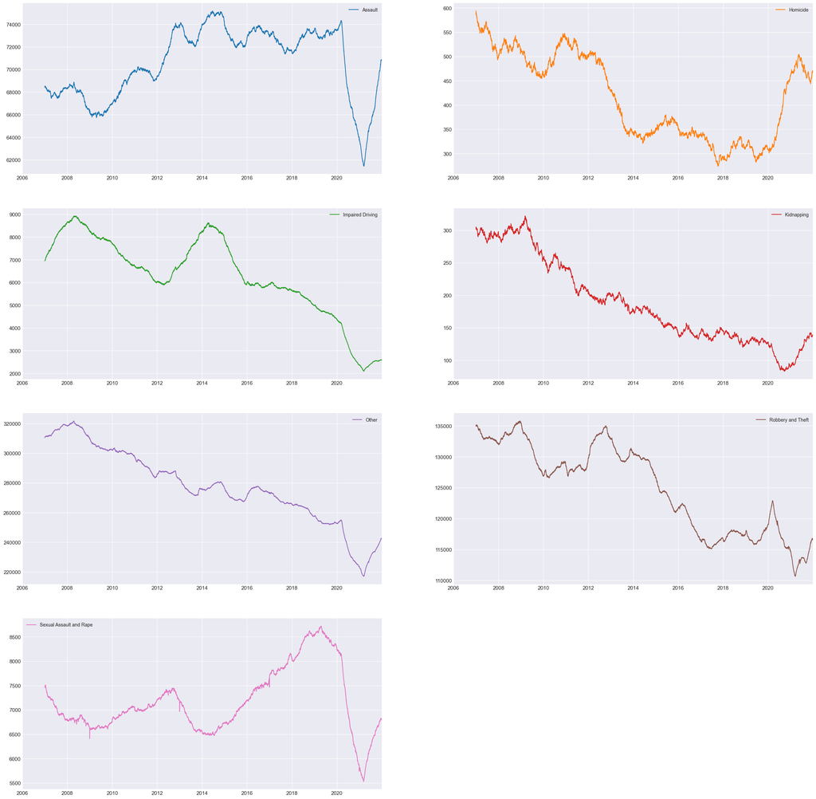

```python
crimes_count_date = df.pivot_table('ID',aggfunc=np.size, columns='Offense', index=df.index.date, fill_value=0)
crimes_count_date.index = pd.DatetimeIndex(crimes_count_date.index)
plt.rcParams['ytick.labelsize'] = 11
plt.rcParams['xtick.labelsize'] = 11
plot = crimes_count_date.rolling(365).sum().plot(figsize=(30, 30), subplots=True, layout=(-1, 2), sharex=False, sharey=False)
plt.style.use(['seaborn-darkgrid'])
```

A most immediate observation is the effect COVID-19 had initially on various crimes. In all metrics except homocide (which seemingly shot up), crime went substantially down.

Something discussed during the begining of the pandemic was the percieved uptick in crime against Asian Americans

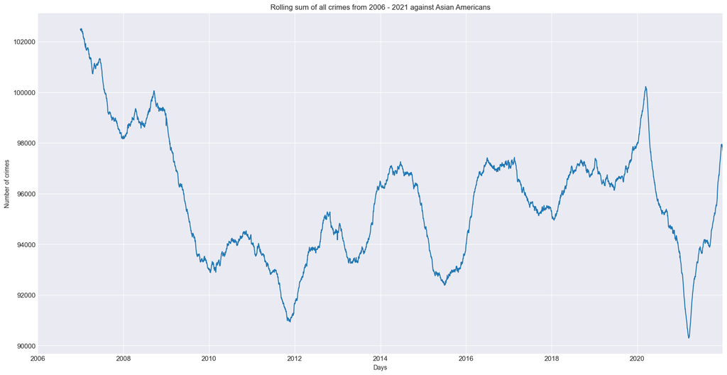

```python
df_asian = df[(df['Victim Race'].isna() == False) & (df['Victim Race'].str.contains("ASIAN"))]
plt.figure(figsize=(20,10))
df_asian.index = df_asian['Date']
df_asian.resample('D').size().rolling(365).sum().plot()
plt.title(f"Rolling sum of all crimes from {df_asian.iloc[-1]['Date'].year} - {df_asian.iloc[0]['Date'].year} against Asian Americans")
plt.ylabel('Number of crimes')
plt.xlabel('Days')
plt.show()
```

This graphs does not tell us much, as these are raw numbers, so it would be much more useful to normalize with the population fluctuations

Let us visualize the data on a map, and see if we can gain any insights from this. Note the size of this data set is quite large, so we will have to set some initital constraints. The data in the moest recent month

```python
most_recent = df['Date'][0].month
df1 = df[df['Date'] > pd.to_datetime(f"{most_recent - 1}/01/2021")]
print("number of crimes comitted in the last month: ",len(df1))
```

[output not shown]

In order to scatter these crimes, we must first filter out those with missing data. Then all that is left to do is grab the coordinates and plot.

```python
plt.figure(num=None, figsize=(10, 8))
plt.scatter("Longitude", "Latitude", data = df1, c = 'y',alpha = 0.1, edgecolor = 'black', s=2)
plt.grid()
plt.xlabel('long')
plt.ylabel('lat')
plt.title('New York Crime')
plt.tight_layout()
plt.axis('tight')
plt.show()
```

[output not shown]

Plotting such data as a heatmap yields similar results

```python
map_osm = fl.Map(location=[40.730610, -73.935242], zoom_start=11)
map_osm
```

```python
df_heatmap = pd.DataFrame()
df_heatmap = df1[['Latitude', 'Longitude']]
df_heatmap['value'] = 1
HeatMap(df_heatmap,
        min_opacity=0.4,
        blur = 18
               ).add_to(fl.FeatureGroup(name='Heat Map').add_to(map_osm))
fl.LayerControl().add_to(map_osm)

map_osm
```

[output not shown]

These graphs do not really tell much, other than the population density /traffic of each borough. To derive any meaning, we must further cut the data.

Let us first examine the age group of the victime, and see if their is any connection between the location and the crime committed. We will then look at various conditional statistics.

First, we let the built in cluster function in folium cluster our crimes in order to see if we can see some sort of pattern

```python
m = fl.Map(
    location=[40.730610, -73.935242],
    zoom_start=11
)

cluster = MarkerCluster().add_to(m)

for i,x in df_heatmap.iterrows():
    fl.Marker([x['Latitude'], x['Longitude']]).add_to(cluster)

heat = HeatMap(df_heatmap,
                min_opacity=0.2,
                radius=30, blur=20,
                max_zoom=11)
heat.add_to(m)
m
```

[output not shown]